# Part 2

Jane Huber

2/20/2022

### Part A

Homes in Detroit have suffered from poorly assessed home values, which has contributed greatly to foreclosure during a time of economic instability. The UC Irvine Law Review’s [“Taxed Out: Illegal Property Tax Assessments and the Epidemic of Tax Foreclosures in Detroit”](https://scholarship.law.uci.edu/ucilr/vol9/iss4/3/) analyzes the relationship between over-assessing a home and its role in driving foreclosures, exposing government’s role in creating conditions for people to lose their homes. The Harris School of Public Policy at the University of Chicago’s The Center For Municipal Finance produced the report [“An Evaluation of Residential Property Tax Assessments in the City of Detroit, 2016-2018”](https://harris.uchicago.edu/files/evalrespropertytaxasdetroit20162018.pdf) shows how the city of Detroit attempted to correct that mistake, reducing the number of assessments higher than sales, but that it’s still too high.

Big picture, the distribution of assessment values for Detroit has widened, with the mean assessment increasing over time. However, we can still see that there is a concentration of assessment values for lower home valuation.

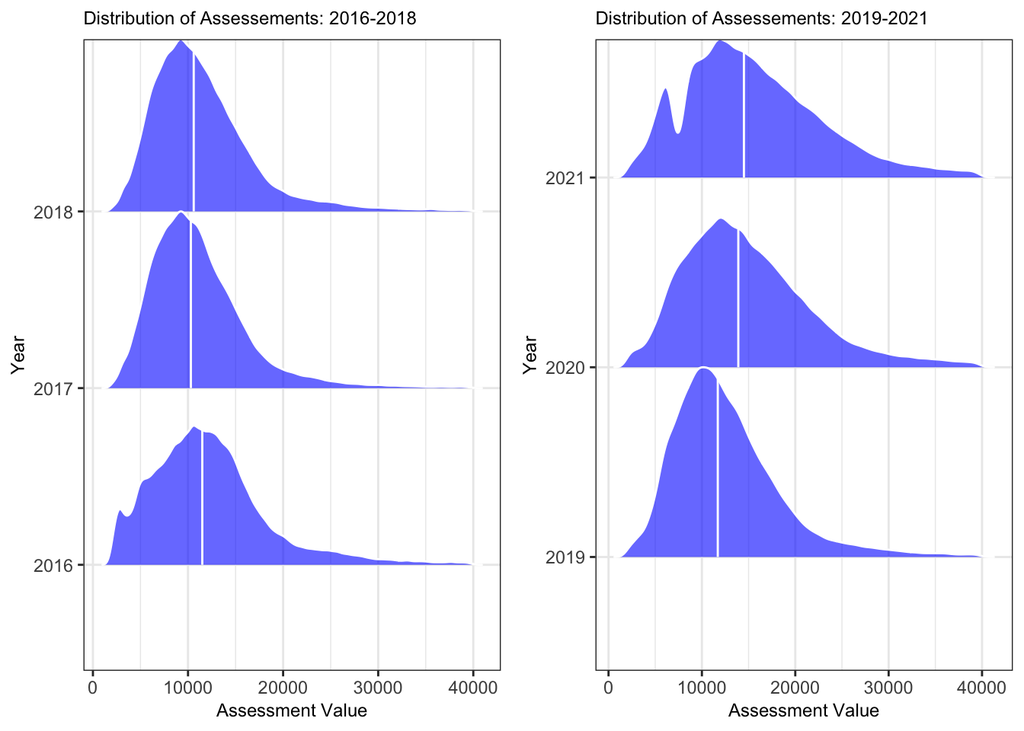

Even as assessments decrease over time, overall sale values have been increasing. This tells us that assessment values are attempting to better respond to and assess more expensive homes for sale in Detroit.

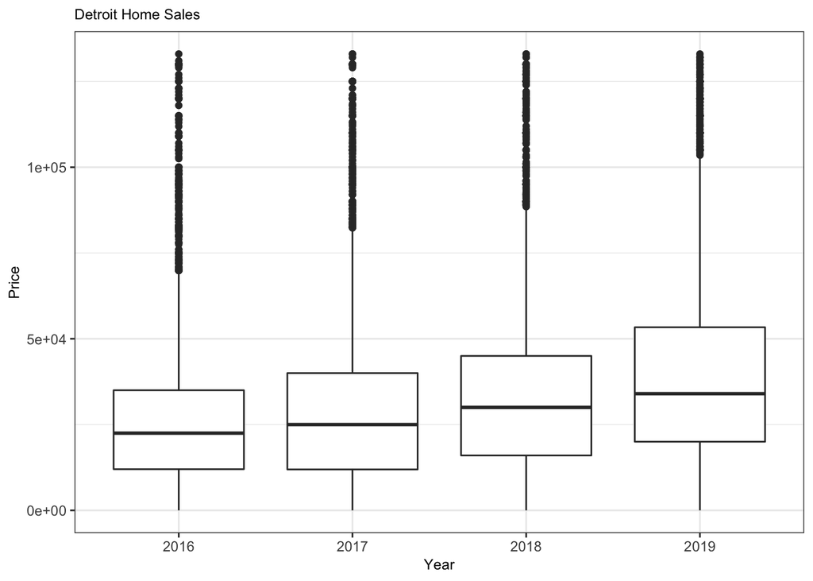

```
## [1] "Filtered out non-arm's length transactions"
## [1] "Inflation adjusted to 2019"
```

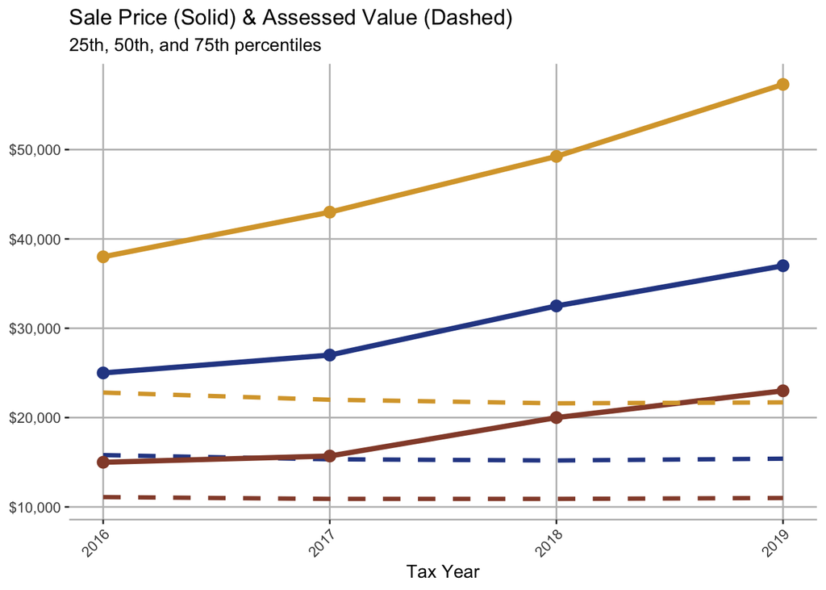

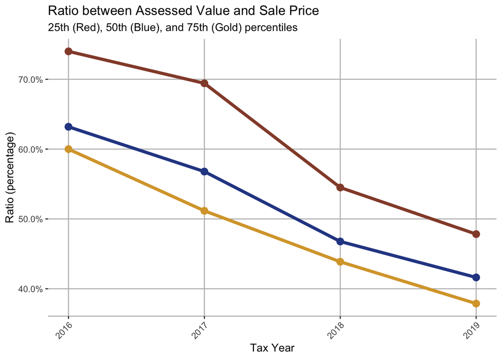

### Part B

Let’s construct a model to determine whether or not a home was overassessed in 2016. We will use logistic regression to help us predict whether something will be “overassessed” or “underassessed”. In Detroit, homes are assessed at 50% value–meaning that if a home was sold for $100,000, it would be assessed for $50,000.

After running our model, it is relatively effective at determining whether or not a property will be overassesed.

| overassessed | predicted_not_overassessed | predicted_overassessed |
| --- | --- | --- |
| NO | 1087 | 338 |
| YES | 209 | 1651 |

[output not shown]

Furthermore, an ROC curve further demonstrates the effectiveness of our model is at determining whether a property is likely to be overassessed.

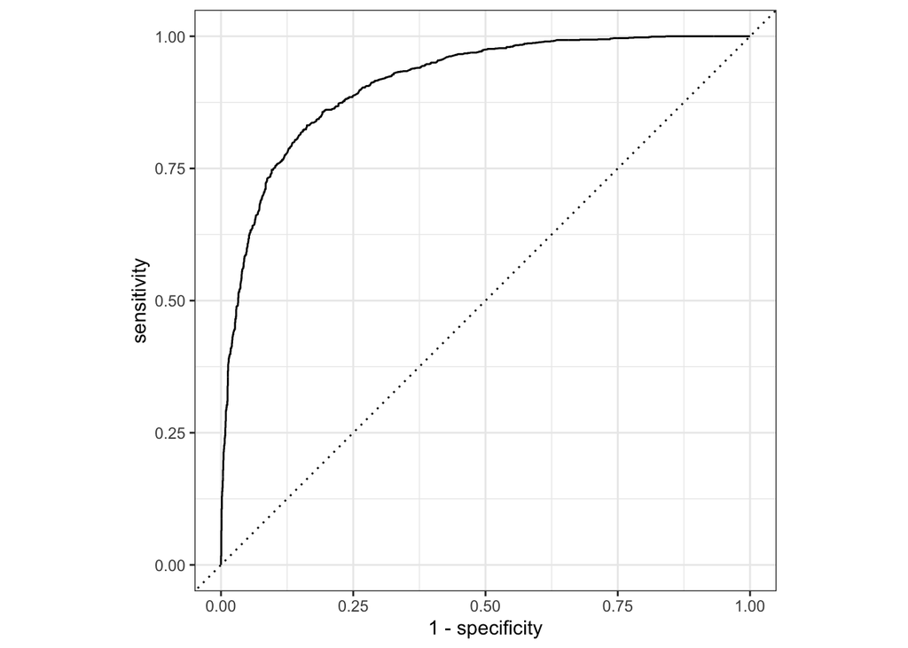

### Part C

Next, we will create a model to predict sale prices for homes in 2019.

Now that we have run the model, we will use MAPE as a first evaluation.

| .metric | .estimator | .estimate |
| --- | --- | --- |
| mape | standard | Inf |

Next, we will use RMSE to further evaluate the model.

| .metric | .estimator | .estimate |
| --- | --- | --- |
| rmse | standard | 30254.9 |